# Examining Performance Tuning Benchmarks v1

This document is intended to address a potential concern with the performance tuning information posted [here](https://github.com/jreynolds01/SQL-Server-R-Services-Samples/tree/master/PerfTuning)

I have not reviewed all the tests, but the issue I did notice is in the third section [Using Integer vs. String in Formula](https://msdn.microsoft.com/en-us/library/mt723571.aspx)

The concerning part is this:

```
## Using Integer vs. String in Formula


In this experiment, rxLinMod was used with the `airline` table
(where `DayOfWeek` is a string) and `airlineWithIndex` (where `DayOfWeek` is an integer).
For the first case, `colInfo` was used to specify the factor levels (Monday, Tuesday, à).
For the second, `colInfo` was not specified. In both case, the same formula was used.
The formula used is `ArrDelay ~ CRSDepTime + DayOfWeek`.
**The following results clearly shows the benefit of using integer vs string:**



| Table name         | Test name | Average time |
|:-------------------|----------:|-------------:|
| airline            | FactorCol | 10.72        |
| airlineWithIntCol  |    IntCol | 3.4475       |
```

**(Emphasis added on my part.)**

The issue is that this investigation confounds two different issues that could drive the difference in performance:

- The storage type in the database
- The complexity of the resulting model that is estimated. Specifically, the `FactorCol` model is more complex because the `DayOfWeek` variable is translated to a set of 6 ‘dummy’ variables in the model. The `IntCol` model only uses 1 variable to cover the `DayOfWeek` variable.

The language above suggests that the effect of the speed up is because of the storage type in the database, but it could be driven by the differences in models.

This document goes through independently testing those two different things (among a few additional pieces below).

The outline of the document is to start by replicating the datasources from the `runtests.R` script, proceed to show that the models are in fact different, and then test whether the difference observed above is due to the model or the data source. Once that is completed, then a few additional tests are done, but those tests don’t change the main upshot of the results.

First, we source the functions used to do the benchmarks, and test them.

```r
source('runtests.R')
```

```
## call runTests(testsToRun, 'Run1', 1, 500000L) to run tests.
```

```r
rxOptions(reportProgress = 0)
```

Let’s replicate the prior examples:

```r
myTestsToRun <- c('FactorCol','IntCol')
runTests(myTestsToRun, 'Run1', 1, 500000L)
```

```
## Running tests with SQL compute context. numTasks =  1  rowsPerRead =  500000
##
## Running FactorCol Test. Using airline table.
##       run  1  took  20  seconds
##       run  2  took  19.5  seconds
##       run  3  took  19.7  seconds
##       run  4  took  19.39  seconds
##       run  5  took  19.29  seconds
##       run  6  took  19.48  seconds
## Average Time:  19.415
##
## Running IntCol Test. Using airlineWithIntCol table.
##       run  1  took  7.08  seconds
##       run  2  took  6.87  seconds
##       run  3  took  6.97  seconds
##       run  4  took  7.28  seconds
##       run  5  took  7.08  seconds
##       run  6  took  7.29  seconds
## Average Time:  7.05
```

## New approach

The code to do the benchmarks is a little complicated in `runtests.R`, and does not allow for inspecting the actual models for equivalency, so I will use a slightly different approach. I will use the `microbenchmark` package to do the benchmarks.

Let’s make sure it’s installed:

```r
if(!require(microbenchmark)) {
    install.packages('microbenchmark')
    library(microbenchmark)
}
```

From `runtests.R`, the key code is in the `runtests` function, and I’ve replicated the version as of 12/16/2016 below:

```r
if ("FactorCol" %in% testsToRun) {
    colInfo <- getColInfoForSqlDataSource(airlineXdf, c("DayOfWeek"), FALSE)
    formula <- ArrDelay ~ CRSDepTime + DayOfWeek
    airlineTable <- RxSqlServerData(table="airline", connectionString = sqlConnString, colInfo = colInfo)
    cat("\nRunning FactorCol Test. Using airline table.", "\n")
    testResult <- runTest(resultDir, "rxLinMod", formula = formula, dataSource = airlineTable, transformFunc = NULL, transformVars = NULL, runs=5)
    cat("Average Time: ", testResult$avgTime, "\n")
    times <- processTimings(testResult)
    if (printTimeSplits) {
      print(times)
    }
  }

  if ("IntCol" %in% testsToRun) {
    formula <- ArrDelay ~ CRSDepTime + DayOfWeek
    airlineWithIntCol <- RxSqlServerData(table="airlineWithIntCol", connectionString = sqlConnString)
    cat("\nRunning IntCol Test. Using airlineWithIntCol table.", "\n")
    testResult <- runTest(resultDir, "rxLinMod", formula = formula, dataSource = airlineWithIntCol, transformFunc = NULL, transformVars = NULL, runs=5)
    cat("Average Time: ", testResult$avgTime, "\n")
    times <- processTimings(testResult)
    if (printTimeSplits) {
      print(times)
    }
  }
```

Let’s run the benchmarks with `microbenchmark` instead to try to speed up the process. First, set up the arguments that are passed to `runtests()`, and set up the compute context:

```r
numTasks = 1            ## this is an argument to runTests() (used in the computeContext)
rowsPerRead = 500000L   ## this is an argument to runTests() (This is not used)
bench_times = 5L        ## number of times based on runTests()
rxOptions(reportProgress = 0)
sqlcc <- getSqlComputeContext(numTasks, sqlConnString)
rxSetComputeContext(sqlcc)
```

Next, let’s define the two data sources to be exactly the same as before:

```r
colInfo <- getColInfoForSqlDataSource(airlineXdf, c("DayOfWeek"), FALSE)
airlineTable <- RxSqlServerData(table="airline", connectionString = sqlConnString, colInfo = colInfo)
airlineWithIntCol <- RxSqlServerData(table="airlineWithIntCol", connectionString = sqlConnString)
```

And let’s double check to see that the variables look like we’d expect:

```r
varsToKeep = c('ArrDelay','CRSDepTime','DayOfWeek')
rxGetVarInfo(airlineTable, varsToKeep = varsToKeep)
```

```
## Var 1: ArrDelay, Type: integer
## Var 2: CRSDepTime, Type: numeric
## Var 3: DayOfWeek, Type: factor, no factor levels available
```

```r
rxGetVarInfo(airlineWithIntCol, varsToKeep = varsToKeep)
```

```
## Var 1: ArrDelay, Type: integer
## Var 2: CRSDepTime, Type: numeric
## Var 3: DayOfWeek, Type: numeric, Storage: int64
```

Next, let’s set up the variable as indicated in `runtests()`:

```r
formula0 <- ArrDelay ~ CRSDepTime + DayOfWeek
```

And, now let’s reconstuct the models to show that they are different:

```r
factorModel <- rxLinMod(formula0, data = airlineTable, reportProgress = 0)
```

```
## ======  JRDSVM-PERFT  ( process  1 ) has started run at  2016-12-19 05:50:09.19  ======
## ======  JRDSVM-PERFT  ( process  1 ) has completed run at  2016-12-19 05:50:28.35  ======
## Warning messages:
## 1: In as.POSIXlt.POSIXct(x, tz) : unable to identify current timezone 'C':
## please set environment variable 'TZ'
## 2: In as.POSIXlt.POSIXct(x, tz) : unknown timezone 'localtime'
```

```r
intModel <- rxLinMod(formula0, data = airlineWithIntCol, reportProgress = 0)
```

```
## ======  JRDSVM-PERFT  ( process  1 ) has started run at  2016-12-19 05:50:29.41  ======
## ======  JRDSVM-PERFT  ( process  1 ) has completed run at  2016-12-19 05:50:35.59  ======
## Warning messages:
## 1: In as.POSIXlt.POSIXct(x, tz) : unable to identify current timezone 'C':
## please set environment variable 'TZ'
## 2: In as.POSIXlt.POSIXct(x, tz) : unknown timezone 'localtime'
```

To see that they’re different, you just need to check the coefficients:

```r
coef(factorModel)
```

```
##    (Intercept)     CRSDepTime  DayOfWeek=Mon DayOfWeek=Tues  DayOfWeek=Wed
##     -0.6805221      0.4596914      1.6619914      2.5620815      3.1612037
## DayOfWeek=Thur  DayOfWeek=Fri  DayOfWeek=Sat  DayOfWeek=Sun
##      3.6104924      3.1071631     -0.6654610             NA
```

```r
coef(intModel)
```

```
## (Intercept)  CRSDepTime   DayOfWeek
##   2.8334276   0.4610072  -0.3956531
```

Clearly, the number of coefficients is not equal in the two, so the models are not equivalent. `factorModel` contains 9 coefficients while `intModel` contains 3 coefficients.

Since both the models are different and the storage type is different, we should try to determine which is driving the effect. We can think of the possible outomes in the context of a 2 (data source) x 2 (model) design, where we could have the different options:

- character storage, categorical predictor (`factorModel` above)
- int storage, int predictor (`intModel` above)
- character storage, int predictor (not shown above)
- int storage, factor predictor (not shown above)

You can think of the observed models as being in a diagonal of a 2 x 2 table, where rows correspond to different predictor types, and different columns correspond to different storage types.

|  | int | char |
| --- | --- | --- |
| int | x |  |
| Categorical |  | x |

We can’t tell if the difference is due to the predictor type, or the storage type. This becomes a little more complicated when we can consider that there are different points in time when we can do the variable casting, but for now, let’s hold that constant and test the effects of forcing dummy variable creation during model estimation.

## Check Model Equivalencies

First, let’s make sure the models are equivalent.

Let’s estimate a model that uses character storage, but a numeric predictor:

```r
charStor_intPred_Model <- rxLinMod(ArrDelay ~ CRSDepTime + as.integer(DayOfWeek), data = airlineTable)
```

[output not shown]

[output cut: 153 more lines]

[output not shown]

```r
coef(intModel)
```

```
## (Intercept)  CRSDepTime   DayOfWeek
##   2.8334276   0.4610072  -0.3956531
```

```r
coef(charStor_intPred_Model)
```

```
##           (Intercept)            CRSDepTime as.integer(DayOfWeek)
##             2.8334276             0.4610072            -0.3956531
```

```r
all(coef(intModel) == coef(charStor_intPred_Model))
```

```
## [1] TRUE
```

The model is equivalent to the `intModel` above.

Now, let’s test the model that uses int storage, but a categorical predictor:

```r
intStor_catPred_Model <- rxLinMod(ArrDelay ~ CRSDepTime + F(DayOfWeek, 1, 7), data = airlineWithIntCol)
```

[output not shown]

[output cut: 153 more lines]

[output not shown]

```r
coef(factorModel)
```

```
##    (Intercept)     CRSDepTime  DayOfWeek=Mon DayOfWeek=Tues  DayOfWeek=Wed
##     -0.6805221      0.4596914      1.6619914      2.5620815      3.1612037
## DayOfWeek=Thur  DayOfWeek=Fri  DayOfWeek=Sat  DayOfWeek=Sun
##      3.6104924      3.1071631     -0.6654610             NA
```

```r
coef(intStor_catPred_Model)
```

```
##         (Intercept)          CRSDepTime F_DayOfWeek_1_7_T=1
##          -0.6805221           0.4596914           1.6619914
## F_DayOfWeek_1_7_T=2 F_DayOfWeek_1_7_T=3 F_DayOfWeek_1_7_T=4
##           2.5620815           3.1612037           3.6104924
## F_DayOfWeek_1_7_T=5 F_DayOfWeek_1_7_T=6 F_DayOfWeek_1_7_T=7
##           3.1071631          -0.6654610                  NA
```

```r
all(coef(factorModel)[!is.na(coef(factorModel))] == coef(intStor_catPred_Model)[!is.na(coef(intStor_catPred_Model))])
```

```
## [1] TRUE
```

```r
rxOptions(reportProgress = 0)
mb_results <- microbenchmark(
charStorage_factorModel = rxLinMod(ArrDelay ~ CRSDepTime + DayOfWeek,             data = airlineTable, reportProgress = 0),
intStorage_factorModel  = rxLinMod(ArrDelay ~ CRSDepTime + F(DayOfWeek, 1, 7),    data = airlineWithIntCol, reportProgress = 0),
charStorage_intModel    = rxLinMod(ArrDelay ~ CRSDepTime + as.integer(DayOfWeek), data = airlineTable, reportProgress = 0),
intStorage_intModel     = rxLinMod(ArrDelay ~ CRSDepTime + DayOfWeek,             data = airlineWithIntCol, reportProgress = 0),
times = bench_times
)
```

[output not shown]

[output cut: 65 more lines]

[output not shown]

Let’s now see the results and visualize it with ggplot2.

```r
if(!require(ggplot2)){
    install.packages('ggplot2')
    library(ggplot2)
}
```

Let’s plot it

```r
mb_results
```

```
## Unit: seconds
##                     expr       min        lq      mean    median        uq       max neval
##  charStorage_factorModel 19.512345 19.601191 19.720605 19.627893 19.841586 20.020010     5
##   intStorage_factorModel  6.863819  6.979298  6.980139  6.981179  7.010818  7.065581     5
##     charStorage_intModel 22.937472 23.163630 23.420663 23.433157 23.650698 23.918359     5
##      intStorage_intModel  6.896629  6.972920  7.016319  6.978057  7.065091  7.168899     5
```

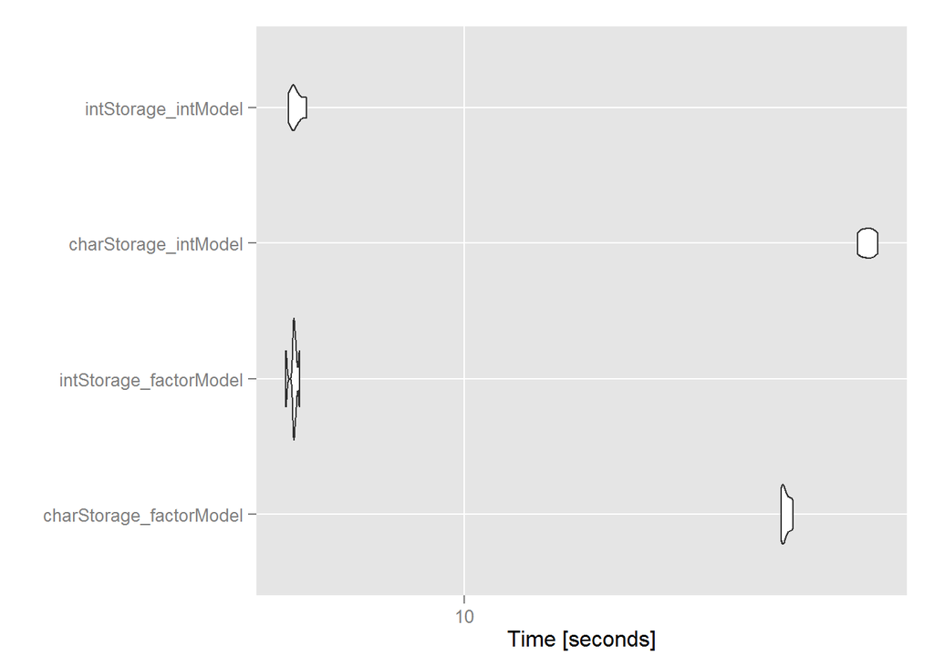

```r
autoplot(mb_results)
```

```r
save(mb_results, file = 'mb_results.Rda')
```

charStorage does make it take longer, and it’s not the creation of the extra variables in the model.

So, it looks like storage method does in fact make a difference…

If we wanted to actually run more, and look at either effect sizes or statistical significance:

```r
varsMat <- matrix(unlist(strsplit(as.character(mb_results$expr), split = '_')), ncol = 2, byrow = TRUE)
mb_results$storageType <- factor(varsMat[,1])
mb_results$modelType <- factor(varsMat[,2])
myAov <- aov(time/1e9 ~ storageType*modelType, data = mb_results)

summary(myAov)
```

```
##                       Df Sum Sq Mean Sq F value   Pr(>F)
## storageType            1 1061.8  1061.8 20322.9  < 2e-16 ***
## modelType              1   17.4    17.4   334.0 3.83e-12 ***
## storageType:modelType  1   16.8    16.8   321.2 5.16e-12 ***
## Residuals             16    0.8     0.1
## ---
## Signif. codes:  0 '***' 0.001 '**' 0.01 '*' 0.05 '.' 0.1 ' ' 1
```

A few more investigations of these effects and ancillary options can be found in `perftuning_follow-ups.Rmd.`